# GDC Clinical Report

#### **Correlation between primary_diagnosis and morphology**

##### **Field values without 1:1 Correspondence:**

Table 1: Primary Diagnosis and Morphoogy values without 1:1 correspondence

| Primary Diagnosis | Morphology | Frequency |
| --- | --- | --- |
| Squamous cell carcinoma, NOS | 8070/3 | 2563 |
| Squamous cell carcinoma, NOS | 8070/33 | 1 |
| Adenocarcinoma, NOS | 8140/3 | 3595 |
| Not Reported | 8140/3 | 1 |
| Not Reported | 8140/6 | 1 |
| Not Reported | 8213/0 | 1 |
| Adrenal cortical carcinoma | 8370/1 | 10 |
| Adrenal cortical carcinoma | 8370/3 | 166 |
| Serous adenocarcinoma, NOS | 8441/3 | 95 |
| Serous cystadenocarcinoma, NOS | 8441/3 | 1410 |
| Mucinous adenocarcinoma | 8480/3 | 281 |
| Mucinous carcinoma | 8480/3 | 1 |
| Infiltrating duct carcinoma, NOS | 8500/3 | 2130 |
| Not Reported | 8500/6 | 1 |
| Intraductal papillary adenocarcinoma with invasion | 8503/3 | 10 |
| Intraductal papillary carcinoma | 8503/3 | 1 |
| Infiltrating lobular carcinoma, NOS | 8520/3 | 10 |
| Lobular carcinoma, NOS | 8520/3 | 386 |
| Infiltrating duct and lobular carcinoma | 8522/1 | 1 |
| Infiltrating duct and lobular carcinoma | 8522/3 | 57 |
| Infiltrating duct and mucinous carcinoma | 8523/3 | 1 |
| Infiltrating duct mixed with other types of carcinoma | 8523/3 | 36 |
| Thymoma, type AB, malignant | 8582/1 | 2 |
| Thymoma, type AB, NOS | 8582/1 | 12 |
| Thymoma, type AB, malignant | 8582/3 | 48 |
| Not Reported | 8720/6 | 8 |
| Not Reported | 8801/6 | 1 |
| Glioblastoma | 9440/3 | 1396 |
| Not Reported | 9440/3 | 1 |
| Leukemia, NOS | 9800/3 | 1 |
| Mixed phenotype acute leukemia with t(9;22)(q34;q11.2); BCR-ABL1 | 9800/3 | 1 |
| Mixed phenotype acute leukemia, B/myeloid, NOS | 9800/3 | 16 |
| Mixed phenotype acute leukemia, T/myeloid, NOS | 9800/3 | 12 |
| Adenocarcinoma, NOS | Not Reported | 27 |
| Angiosarcoma | Not Reported | 33 |
| Ductal carcinoma in situ, NOS | Not Reported | 1 |
| Infiltrating duct and lobular carcinoma | Not Reported | 11 |
| Infiltrating duct and mucinous carcinoma | Not Reported | 1 |
| Infiltrating duct carcinoma, NOS | Not Reported | 116 |
| Infiltrating lobular carcinoma, NOS | Not Reported | 13 |
| Invasive lobular carcinoma | Not Reported | 1 |
| Not Reported | Not Reported | 39 |
| Unknown | Not Reported | 1 |

#### **site_of_resection_or_biopsy**

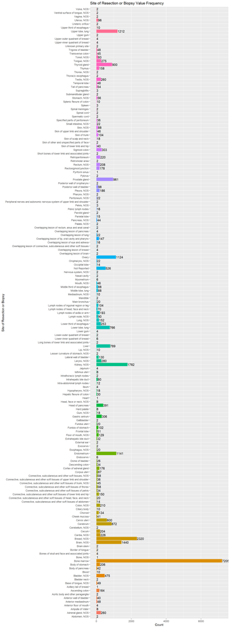

There were 2 NA entries.

##### Unused Values:

333 total field values, 168 unused values listed below.

*Abdominal esophagus*, *Accessory sinus, NOS*, *Acoustic nerve*, *Anal canal*, *Anterior 2/3 of tongue, NOS*, *Anterior surface of epiglottis*, *Anterior wall of nasopharynx*, *Anus, NOS*, *Appendix*, *Autonomic nervous system, NOS*, *Biliary tract, NOS*, *Body of penis*, *Bone of limb, NOS*, *Branchial cleft*, *Broad ligament*, *Carotid body*, *Cauda equina*, *Central portion of breast*, *Cerebral meninges*, *Cervical esophagus*, *Clitoris*, *Cloacogenic zone*, *Commissure of lip*, *Conjunctiva*, *Cornea, NOS*, *Cranial nerve, NOS*, *Craniopharyngeal duct*, *Descended testis*, *Dorsal surface of tongue, NOS*, *Duodenum*, *Endocrine gland, NOS*, *Epididymis*, *Ethmoid sinus*, *External lip, NOS*, *External lower lip*, *External upper lip*, *Eye, NOS*, *Eyelid*, *Fallopian tube*, *Female genital tract, NOS*, *Frontal sinus*, *Gastrointestinal tract, NOS*, *Glans penis*, *Glottis*, *Greater curvature of stomach, NOS*, *Hematopoietic system, NOS*, *Hypopharyngeal aspect of aryepiglottic fold*, *Ill-defined sites within respiratory system*, *Intestinal tract, NOS*, *Islets of Langerhans*, *Labium majus*, *Labium minus*, *Lacrimal gland*, *Laryngeal cartilage*, *Lateral floor of mouth*, *Lateral wall of nasopharynx*, *Lateral wall of oropharynx*, *Lingual tonsil*, *Long bones of upper limb, scapula and associated joints*, *Lower limb, NOS*, *Lymph nodes of multiple regions*, *Major salivary gland, NOS*, *Male genital organs, NOS*, *Maxillary sinus*, *Meckel diverticulum*, *Medulla of adrenal gland*, *Meninges, NOS*, *Middle ear*, *Mucosa of lip, NOS*, *Mucosa of lower lip*, *Mucosa of upper lip*, *Nasopharynx, NOS*, *Nipple*, *Olfactory nerve*, *Optic nerve*, *Orbit, NOS*, *Other ill-defined sites*, *Other specified parts of female genital organs*, *Other specified parts of male genital organs*, *Other specified parts of pancreas*, *Overlapping lesion of accessory sinuses*, *Overlapping lesion of biliary tract*, *Overlapping lesion of bladder*, *Overlapping lesion of bones, joints and articular cartilage*, *Overlapping lesion of bones, joints and articular cartilage of limbs*, *Overlapping lesion of brain and central nervous system*, *Overlapping lesion of cervix uteri*, *Overlapping lesion of colon*, *Overlapping lesion of corpus uteri*, *Overlapping lesion of digestive system*, *Overlapping lesion of endocrine glands and related structures*, *Overlapping lesion of esophagus*, *Overlapping lesion of female genital organs*, *Overlapping lesion of floor of mouth*, *Overlapping lesion of heart, mediastinum and pleura*, *Overlapping lesion of hypopharynx*, *Overlapping lesion of ill-defined sites*, *Overlapping lesion of larynx*, *Overlapping lesion of lip*, *Overlapping lesion of major salivary glands*, *Overlapping lesion of male genital organs*, *Overlapping lesion of nasopharynx*, *Overlapping lesion of other and unspecified parts of mouth*, *Overlapping lesion of palate*, *Overlapping lesion of penis*, *Overlapping lesion of peripheral nerves and autonomic nervous system*, *Overlapping lesion of respiratory system and intrathoracic organs*, *Overlapping lesion of retroperitoneum and peritoneum*, *Overlapping lesion of skin*, *Overlapping lesion of small intestine*, *Overlapping lesion of stomach*, *Overlapping lesion of tongue*, *Overlapping lesion of tonsil*, *Overlapping lesion of urinary organs*, *Overlapping lesion of vulva*, *Overlapping lesions of oropharynx*, *Pancreatic duct*, *Pancreatic neck*, *Parametrium*, *Parathyroid gland*, *Paraurethral gland*, *Pelvic bones, sacrum, coccyx and associated joints*, *Penis, NOS*, *Peripheral nerves and autonomic nervous system of abdomen*, *Peripheral nerves and autonomic nervous system of head, face, and neck*, *Peripheral nerves and autonomic nervous system of lower limb and hip*, *Peripheral nerves and autonomic nervous system of pelvis*, *Peripheral nerves and autonomic nervous system of thorax*, *Peripheral nerves and autonomic nervous system of trunk, NOS*, *Pineal gland*, *Pituitary gland*, *Placenta*, *Postcricoid region*, *Posterior mediastinum*, *Posterior wall of hypopharynx*, *Posterior wall of nasopharynx*, *Prepuce*, *Renal pelvis*, *Reticuloendothelial system, NOS*, *Retina*, *Rib, sternum, clavicle and associated joints*, *Round ligament*, *Scrotum, NOS*, *Short bones of upper limb and associated joints*, *Skin of lip, NOS*, *Soft palate, NOS*, *Sphenoid sinus*, *Subglottis*, *Sublingual gland*, *Superior wall of nasopharynx*, *Tonsillar fossa*, *Tonsillar pillar*, *Trachea*, *Undescended testis*, *Upper limb, NOS*, *Upper respiratory tract, NOS*, *Urachus*, *Ureter*, *Urethra*, *Urinary system, NOS*, *Uterine adnexa*, *Uvula*, *Vallecula*, *Ventricle, NOS*, *Vertebral column*, *Vestibule of mouth*, *Waldeyer ring* and *Unknown*

#### **tissue_or_organ_of_origin**

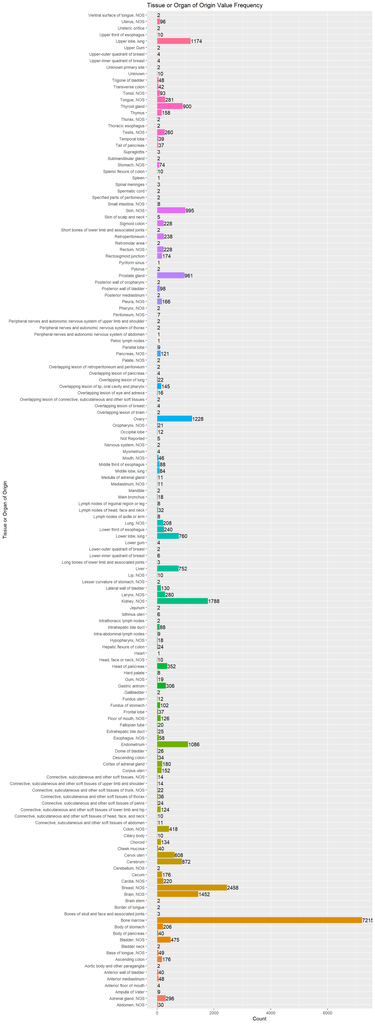

There were 30 NA entries.

##### Unused Values:

333 total field values, 180 unused values listed below.

*Abdominal esophagus*, *Accessory sinus, NOS*, *Acoustic nerve*, *Anal canal*, *Anterior 2/3 of tongue, NOS*, *Anterior surface of epiglottis*, *Anterior wall of nasopharynx*, *Anus, NOS*, *Appendix*, *Autonomic nervous system, NOS*, *Axillary tail of breast*, *Biliary tract, NOS*, *Blood*, *Body of penis*, *Bone of limb, NOS*, *Bone, NOS*, *Branchial cleft*, *Broad ligament*, *Carotid body*, *Cauda equina*, *Central portion of breast*, *Cerebral meninges*, *Cervical esophagus*, *Clitoris*, *Cloacogenic zone*, *Commissure of lip*, *Conjunctiva*, *Cornea, NOS*, *Cranial nerve, NOS*, *Craniopharyngeal duct*, *Descended testis*, *Dorsal surface of tongue, NOS*, *Duodenum*, *Endocervix*, *Endocrine gland, NOS*, *Epididymis*, *Ethmoid sinus*, *Exocervix*, *External ear*, *External lip, NOS*, *External lower lip*, *External upper lip*, *Eye, NOS*, *Eyelid*, *Female genital tract, NOS*, *Frontal sinus*, *Gastrointestinal tract, NOS*, *Glans penis*, *Glottis*, *Greater curvature of stomach, NOS*, *Hematopoietic system, NOS*, *Hypopharyngeal aspect of aryepiglottic fold*, *Ileum*, *Ill-defined sites within respiratory system*, *Intestinal tract, NOS*, *Islets of Langerhans*, *Labium majus*, *Labium minus*, *Lacrimal gland*, *Laryngeal cartilage*, *Laryngeal commissure*, *Lateral floor of mouth*, *Lateral wall of nasopharynx*, *Lateral wall of oropharynx*, *Lingual tonsil*, *Long bones of upper limb, scapula and associated joints*, *Lower limb, NOS*, *Lymph node, NOS*, *Lymph nodes of multiple regions*, *Major salivary gland, NOS*, *Male genital organs, NOS*, *Maxillary sinus*, *Meckel diverticulum*, *Meninges, NOS*, *Middle ear*, *Mucosa of lip, NOS*, *Mucosa of lower lip*, *Mucosa of upper lip*, *Nasal cavity*, *Nasopharynx, NOS*, *Nipple*, *Olfactory nerve*, *Optic nerve*, *Orbit, NOS*, *Other ill-defined sites*, *Other specified parts of female genital organs*, *Other specified parts of male genital organs*, *Other specified parts of pancreas*, *Overlapping lesion of accessory sinuses*, *Overlapping lesion of biliary tract*, *Overlapping lesion of bladder*, *Overlapping lesion of bones, joints and articular cartilage*, *Overlapping lesion of bones, joints and articular cartilage of limbs*, *Overlapping lesion of brain and central nervous system*, *Overlapping lesion of cervix uteri*, *Overlapping lesion of colon*, *Overlapping lesion of corpus uteri*, *Overlapping lesion of digestive system*, *Overlapping lesion of endocrine glands and related structures*, *Overlapping lesion of esophagus*, *Overlapping lesion of female genital organs*, *Overlapping lesion of floor of mouth*, *Overlapping lesion of heart, mediastinum and pleura*, *Overlapping lesion of hypopharynx*, *Overlapping lesion of ill-defined sites*, *Overlapping lesion of larynx*, *Overlapping lesion of lip*, *Overlapping lesion of major salivary glands*, *Overlapping lesion of male genital organs*, *Overlapping lesion of nasopharynx*, *Overlapping lesion of other and unspecified parts of mouth*, *Overlapping lesion of palate*, *Overlapping lesion of penis*, *Overlapping lesion of peripheral nerves and autonomic nervous system*, *Overlapping lesion of rectum, anus and anal canal*, *Overlapping lesion of respiratory system and intrathoracic organs*, *Overlapping lesion of skin*, *Overlapping lesion of small intestine*, *Overlapping lesion of stomach*, *Overlapping lesion of tongue*, *Overlapping lesion of tonsil*, *Overlapping lesion of urinary organs*, *Overlapping lesion of vulva*, *Overlapping lesions of oropharynx*, *Pancreatic duct*, *Parametrium*, *Parathyroid gland*, *Paraurethral gland*, *Parotid gland*, *Pelvic bones, sacrum, coccyx and associated joints*, *Pelvis, NOS*, *Penis, NOS*, *Peripheral nerves and autonomic nervous system of head, face, and neck*, *Peripheral nerves and autonomic nervous system of lower limb and hip*, *Peripheral nerves and autonomic nervous system of pelvis*, *Peripheral nerves and autonomic nervous system of trunk, NOS*, *Pineal gland*, *Pituitary gland*, *Placenta*, *Postcricoid region*, *Posterior wall of hypopharynx*, *Posterior wall of nasopharynx*, *Prepuce*, *Renal pelvis*, *Reticuloendothelial system, NOS*, *Retina*, *Rib, sternum, clavicle and associated joints*, *Round ligament*, *Scrotum, NOS*, *Short bones of upper limb and associated joints*, *Skin of lip, NOS*, *Skin of lower limb and hip*, *Skin of other and unspecified parts of face*, *Skin of trunk*, *Skin of upper limb and shoulder*, *Soft palate, NOS*, *Sphenoid sinus*, *Spinal cord*, *Subglottis*, *Sublingual gland*, *Superior wall of nasopharynx*, *Tonsillar fossa*, *Tonsillar pillar*, *Trachea*, *Undescended testis*, *Upper limb, NOS*, *Upper respiratory tract, NOS*, *Urachus*, *Ureter*, *Urethra*, *Urinary system, NOS*, *Uterine adnexa*, *Uvula*, *Vagina, NOS*, *Vallecula*, *Ventricle, NOS*, *Vertebral column*, *Vestibule of mouth*, *Vulva, NOS* and *Waldeyer ring*

#### **Correlation between site_of_resection_or_biopsy and tissue_or_organ_of_origin**

##### **Field values without 1:1 Correspondence:**

| Site of Resection or Biopsy | Tissue or Organ of origin | Frequency |
| --- | --- | --- |
| Not Reported | Abdomen, NOS | 29 |
| Pelvis, NOS | Abdomen, NOS | 1 |
| Adrenal gland, NOS | Adrenal gland, NOS | 252 |
| Intra-abdominal lymph nodes | Adrenal gland, NOS | 2 |
| Not Reported | Adrenal gland, NOS | 42 |
| Ampulla of Vater | Ampulla of Vater | 8 |
| Lymph node, NOS | Ampulla of Vater | 1 |
| Ascending colon | Ascending colon | 160 |
| Cecum | Ascending colon | 8 |
| Hepatic flexure of colon | Ascending colon | 6 |
| Transverse colon | Ascending colon | 2 |
| Body of pancreas | Body of pancreas | 40 |
| Blood | Bone marrow | 10 |
| Bone marrow | Bone marrow | 7205 |
| Bones of skull and face and associated joints | Bones of skull and face and associated joints | 2 |
| Not Reported | Bones of skull and face and associated joints | 1 |
| Brain, NOS | Brain, NOS | 1426 |
| Frontal lobe | Brain, NOS | 10 |
| Occipital lobe | Brain, NOS | 1 |
| Parietal lobe | Brain, NOS | 5 |
| Temporal lobe | Brain, NOS | 10 |
| Axillary tail of breast | Breast, NOS | 1 |
| Bone, NOS | Breast, NOS | 1 |
| Breast, NOS | Breast, NOS | 2320 |
| Not Reported | Breast, NOS | 136 |
| Cardia, NOS | Cardia, NOS | 220 |
| Ascending colon | Cecum | 4 |
| Cecum | Cecum | 172 |
| Cervix uteri | Cervix uteri | 600 |
| Endocervix | Cervix uteri | 6 |

[output cut: 184 more lines]

#### **ajcc_clinical_m**

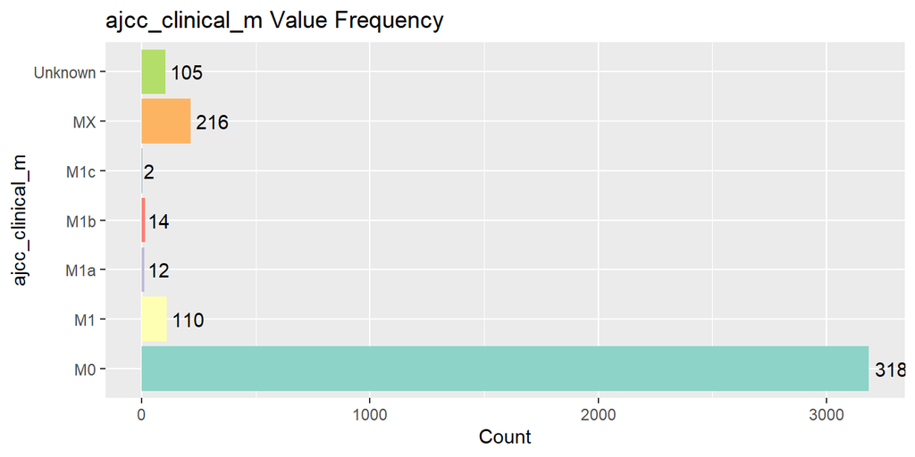

There were 26792 NA entries.

##### Unused Values:

- cM0 (i+)
- Not Reported

#### **ajcc_clinical_n**

[figure not shown]

There were 28463 NA entries.

##### Unused Values:

*N0 (i+)*, *N0 (i-)*, *N0 (mol+)*, *N0 (mol-)*, *N1a*, *N1b*, *N1bI*, *N1bII*, *N1bIII*, *N1bIV*, *N1c*, *N1mi*, *N3a*, *N3b*, *N3c*, *N4*, *Unknown* and *Not Reported*

#### **ajcc_clinical_stage**

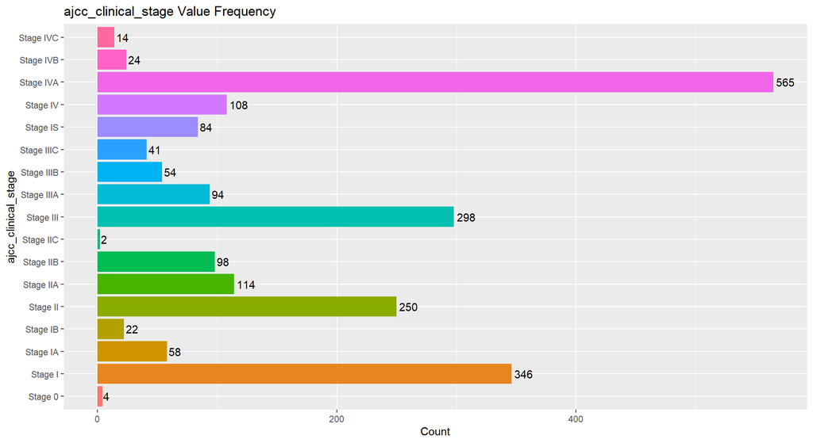

There were 28259 NA entries.

##### Unused Values:

*Stage 0a*, *Stage 0is*, *Stage IA1*, *Stage IA2*, *Stage IA3*, *Stage IB1*, *Stage IB2*, *Stage IC*, *Stage IIA1*, *Stage IIA2*, *Stage IIC1*, *Stage IIIC1*, *Stage IIIC2*, *Stage Tis*, *Stage X*, *Unknown* and *Not Reported*

#### **ajcc_clinical_t**

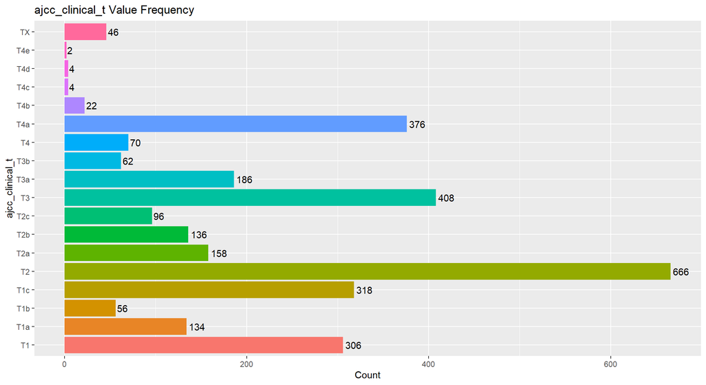

There were 27385 NA entries.

##### Unused Values:

*T0*, *T1a1*, *T1a2*, *T1b1*, *T1b2*, *T1mi*, *T2a1*, *T2a2*, *T2d*, *T3c*, *T3d*, *Ta*, *Tis*, *Tis (DCIS)*, *Tis (LCIS)*, *Tis (Paget’s)*, *Unknown* and *Not Reported*

#### ajcc_pathologic_m

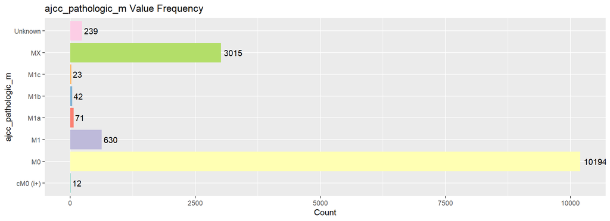

There were 16209 NA entries.

##### Unused Values:

- M1d
- M2
- Not Reported

#### **Correlation between ajcc_clinical_m and ajcc_pathologic_m**

##### **Field values without 1:1 Correspondence:**

Table 3: ajcc_clinical_m and ajcc_pathologic_m without 1:1 correspondence

| ajcc_clinical_m | ajcc_pathologic_m | Frequency |
| --- | --- | --- |
| M0 | ’– | 1624 |
| M1 | ’– | 54 |
| M1a | ’– | 4 |
| M1b | ’– | 6 |
| M1c | ’– | 2 |
| MX | ’– | 16 |
| ’– | cM0 (i+) | 12 |
| ’– | M0 | 9101 |
| M0 | M0 | 1024 |
| M1 | M0 | 9 |
| M1a | M0 | 4 |
| MX | M0 | 28 |
| Unknown | M0 | 28 |
| ’– | M1 | 589 |
| M0 | M1 | 7 |
| M1 | M1 | 30 |
| M1b | M1 | 2 |
| MX | M1 | 2 |
| ’– | M1a | 67 |
| M1a | M1a | 4 |
| ’– | M1b | 36 |
| M1b | M1b | 6 |
| ’– | M1c | 23 |
| ’– | MX | 2461 |
| M0 | MX | 374 |
| M1 | MX | 10 |
| MX | MX | 170 |
| M0 | Unknown | 155 |
| M1 | Unknown | 7 |
| Unknown | Unknown | 77 |

#### **ajcc_pathologic_n**

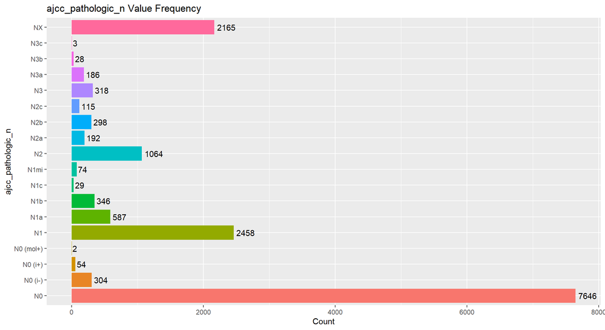

There were 14566 NA entries.

##### Unused Values:

*N0 (mol-)*, *N1bI*, *N1bII*, *N1bIII*, *N1bIV*, *N4*, *Unknown* and *Not Reported*

There were 14566 NA entries.

#### **Correlation between ajcc_clinical_n and ajcc_pathologic_n**

##### **Field values without 1:1 Correspondence:**

Table 4: ajcc_clinical_n and ajcc_pathologic_n without 1:1 correspondence

| ajcc_clinical_n | ajcc_pathologic_n | Frequency |
| --- | --- | --- |
| N0 | ’– | 32 |
| N1 | ’– | 22 |
| N2 | ’– | 2 |
| N2a | ’– | 10 |
| N2b | ’– | 16 |
| N2c | ’– | 4 |
| N3 | ’– | 8 |
| NX | ’– | 12 |
| ’– | N0 | 6980 |
| N0 | N0 | 582 |
| N1 | N0 | 42 |
| N2 | N0 | 2 |
| N2a | N0 | 2 |
| N2b | N0 | 10 |
| N2c | N0 | 8 |
| N3 | N0 | 2 |
| NX | N0 | 18 |
| ’– | N0 (i-) | 304 |
| ’– | N0 (i+) | 54 |
| ’– | N0 (mol+) | 2 |
| ’– | N1 | 2230 |
| N0 | N1 | 56 |
| N1 | N1 | 136 |
| N2 | N1 | 2 |
| N2a | N1 | 2 |
| N2b | N1 | 8 |
| N2c | N1 | 10 |
| N3 | N1 | 2 |
| NX | N1 | 12 |
| ’– | N1a | 587 |
| ’– | N1b | 346 |
| ’– | N1c | 29 |
| ’– | N1mi | 74 |
| ’– | N2 | 1024 |
| N0 | N2 | 6 |
| N1 | N2 | 6 |
| N2 | N2 | 18 |
| N2b | N2 | 6 |
| NX | N2 | 4 |
| ’– | N2a | 176 |
| N2a | N2a | 2 |
| N2b | N2a | 12 |
| NX | N2a | 2 |
| ’– | N2b | 90 |
| N0 | N2b | 44 |
| N1 | N2b | 44 |
| N2 | N2b | 12 |
| N2a | N2b | 12 |
| N2b | N2b | 80 |
| N2c | N2b | 6 |
| NX | N2b | 10 |
| ’– | N2c | 19 |
| N0 | N2c | 12 |
| N1 | N2c | 10 |
| N2 | N2c | 10 |
| N2a | N2c | 4 |
| N2b | N2c | 14 |
| N2c | N2c | 46 |
| ’– | N3 | 296 |
| N0 | N3 | 2 |
| N2 | N3 | 2 |
| N2b | N3 | 2 |
| N2c | N3 | 2 |
| N3 | N3 | 8 |
| NX | N3 | 6 |
| ’– | N3a | 186 |
| ’– | N3b | 28 |
| ’– | N3c | 3 |
| ’– | NX | 1575 |
| N0 | NX | 356 |
| N1 | NX | 44 |
| N2 | NX | 6 |
| N2a | NX | 2 |
| N2b | NX | 22 |
| N2c | NX | 14 |
| N3 | NX | 6 |
| NX | NX | 140 |

#### **ajcc_pathologic_stage**

[figure not shown]

##### Unused Values:

*Stage 0*, *Stage 0a*, *Stage 0is*, *Stage I*, *Stage IA*, *Stage IA1*, *Stage IA2*, *Stage IA3*, *Stage IB*, *Stage IB1*, *Stage IB2*, *Stage IC*, *Stage II*, *Stage IIA*, *Stage IIA1*, *Stage IIA2*, *Stage IIB*, *Stage IIC*, *Stage IIC1*, *Stage III*, *Stage IIIA*, *Stage IIIB*, *Stage IIIC*, *Stage IIIC1*, *Stage IIIC2*, *Stage IS*, *Stage IV*, *Stage IVA*, *Stage IVB*, *Stage IVC*, *Stage Tis*, *Stage X* and *Not Reported*

#### **ajcc_pathologic_t**

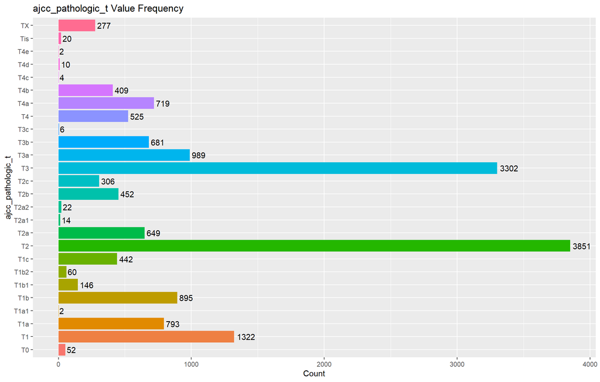

There were 14485 NA entries.

##### Unused Values:

*T1a2*, *T1mi*, *T2d*, *T3d*, *Ta*, *Tis (DCIS)*, *Tis (LCIS)*, *Tis (Paget’s)*, *Unknown* and *Not Reported*

#### **ann_arbor_b_symptoms**

Table 5: ann_arbor_b_symptoms Value Distribution

| ann_arbor_b_symptoms | Frequency |
| --- | --- |
| NA | 30347 |
| No | 68 |
| Yes | 20 |

##### Unused Values:

- Not Reported

#### **ann_arbor_clinical_stage**

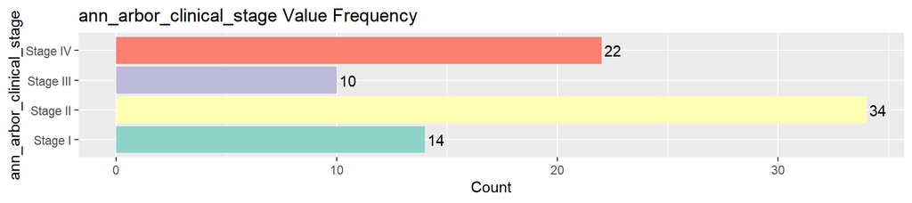

There were 30355 NA entries.

##### Unused Values:

- Unknown
- Not Reported

#### **ann_arbor_extranodal_involvement**

Table 6: ann_arbor_extranodal Value Distribution

| ann_arbor_extranodal_involvement | Frequency |
| --- | --- |
| NA | 30347 |
| No | 50 |
| Yes | 38 |

##### Unused Values:

4 Total Values, 2 unused

- Unknown
- Not Reported

#### **ann_arbor_pathologic_stage**

Table 7: ann_arbor_pathologic_stage Value Distribution

| ann_arbor_pathologic_stage | Frequency |
| --- | --- |
| NA | 30435 |

6 values total, all unused.

#### **best_overall_response**

Table 8: best_overall_response Value Distribution

| best_overall_response | Frequency |
| --- | --- |
| NA | 30435 |

26 values total, all unused.

#### **burkitt_lymphoma_clinical_variant**

Table 9: burkitt_lymphoma_clinical_variant Value Distribution

| burkitt_lymphoma_clinical_variant | Frequency |
| --- | --- |
| NA | 30435 |

7 values total, all unused.

#### **child_pugh_classification**

Table 10: child_pugh_classification Value Distribution

| child_pugh_classification | Frequency |
| --- | --- |
| NA | 30435 |

13 values total, all unused.

#### **classification_of_tumor**

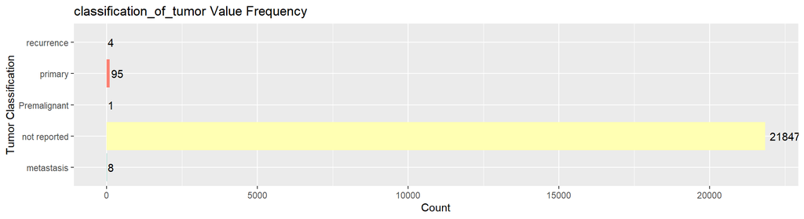

There were 8480 NA entries.

##### Unused Values:

*other*, *premalignant*, *Progression*, *Unknown*, *Not Reported* and *Not Allowed To Collect*

#### **cog_liver_stage**

Table 11: cog_liver_stage Value Distribution

| cog_liver_stage | Frequency |
| --- | --- |
| NA | 30435 |

6 values total, all unused.

#### **cog_neuroblastoma_risk_group**

Table 12: cog_neuroblastoma_risk_group Value Distribution

| cog_neuroblastoma_risk_group | Frequency |
| --- | --- |
| NA | 30435 |

5 values total, all unused.

#### **cog_renal_stage**

Table 13: cog_renal_stage Value Distribution

| cog_renal_stage | Frequency |
| --- | --- |
| NA | 30407 |
| Stage I | 3 |
| Stage II | 9 |
| Stage III | 11 |
| Stage IV | 5 |

##### Unused Values:

6 total values, 2 unknown

- Unknown
- Not Reported

#### **cog_rhabdomyosarcoma_risk_group**

Table 14: cog_rhabdomyosarcoma_risk_group Value Distribution

| cog_rhabdomyosarcoma_risk_group | Frequency |
| --- | --- |
| NA | 30435 |

5 total values, all unused.

#### **eln_risk_classification**

Table 15: eln_risk_classification Value Distribution

| eln_risk_classification | Frequency |
| --- | --- |
| NA | 30435 |

5 total values, all unused.

#### **enneking_msts_grade**

Table 16: enneking_msts_grade Value Distribution

| enneking_msts_grade | Frequency |
| --- | --- |
| NA | 30435 |

4 total values, all unused.

#### **enneking_msts_metastasis**

Table 17: enneking_msts_metastasis Value Distribution

| enneking_msts_metastasis | Frequency |
| --- | --- |
| NA | 30435 |

4 values total, all unused.

#### **enneking_msts_stage**

Table 18: enneking_msts_stage Value Distribution

| enneking_msts_stage | Frequency |
| --- | --- |
| NA | 30435 |

7 values total, all unused.

#### **enneking_msts_tumor_site**

Table 19: enneking_msts_tumor_site Value Distribution

| enneking_msts_tumor_site | Frequency |
| --- | --- |
| NA | 30435 |

4 values total, all unused.

#### **esophageal_columnar_dysplasia_degree**

Table 20: esophageal_columnar_dsyplasia_degree Value Distribution

| esophageal_columnar_dsyplasia_degree | Frequency |
| --- | --- |
| NA | 30405 |
| Unknown | 30 |

##### Unused Values:

6 values total, 5 unused:

- High Grade Dysplasia
- Indefinite for Dysplasia
- Low Grade Dysplasia
- Negative/ No Dysplasia
- Not Reported

#### **esophageal_columnar_metaplasia_present**

Table 21: esophageal_columnar_metaplasia_present Value Distribution

| esophageal_columnar_metaplasia_present | Frequency |
| --- | --- |
| NA | 30405 |
| Unknown | 30 |

##### Unused Values:

4 Values total, 3 Unused:

- Yes
- No
- Not Reported

#### **figo_stage**

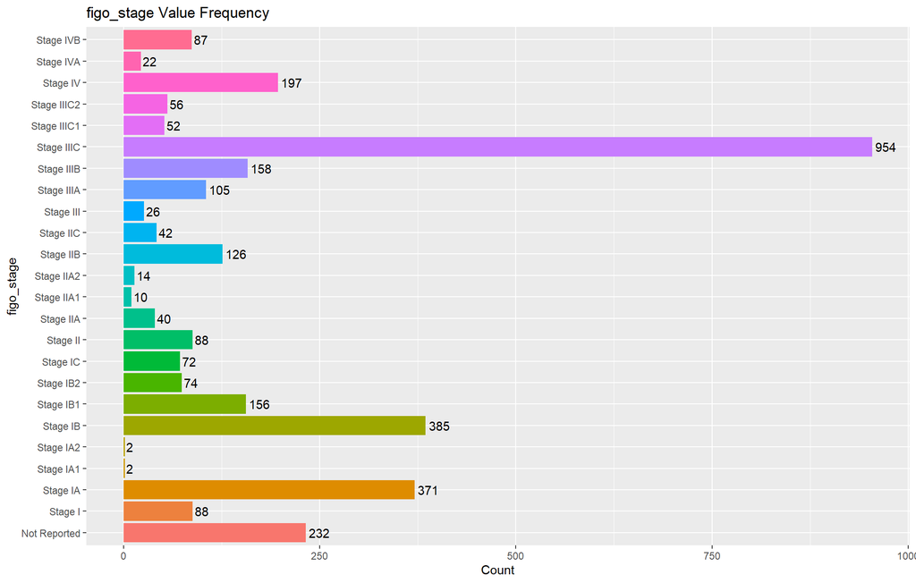

There were 27076 NA entries.

##### Unused Values:

*Stage 0*, *Stage IC1*, *Stage IC2*, *Stage IC3*, *Stage IIIA1*, *Stage IIIA2*, *Stage IIIAi*, *Stage IIIAii* and *Unknown*

#### **figo_staging_edition_year**

Table 22: figo_staging_edition_year Value Distribution

| figo_staging_edition_year | Frequency |
| --- | --- |
| NA | 30435 |

3 values total, all unused.

#### **first_symptom_prior_to_diagnosis**

Table 23: first_symptom_prior_to_diagnosis Value Distribution

| first_symptom_prior_to_diagnosis | Frequency |
| --- | --- |
| NA | 30435 |

8 values total, all unused.

#### **gastric_esophageal_junction_involvement**

Table 24: gastric_esophageal_junction_involvement Value Distribution

| gastric_esophageal_junction_involvement | Frequency |
| --- | --- |
| NA | 30405 |
| Unknown | 30 |

##### Unused Values:

4 values total, 3 unused:

- Yes
- No
- Not Reported

#### **gleason_grade_group**

Table 25: gleason_grade_group Value Distribution

| gleason_grade_group | Frequency |
| --- | --- |
| NA | 30435 |

6 values total, all unused.

#### **gleason_grade_tertiary**

Table 26: gleason_grade_tertiary Value Distribution

| gleason_grade_tertiary | Frequency |
| --- | --- |
| NA | 30435 |

2 values total, both unused.

#### **goblet_cells_columnar_mucosa_present**

Table 27: goblet_cells_columnar_mucosa_present Value Distribution

| goblet_cells_columnar_mucosa_present | Frequency |
| --- | --- |
| NA | 30405 |
| Unknown | 30 |

##### Unused Values:

4 values total, 3 unused.

- Yes
- No
- Not Reported

#### **igcccg_stage**

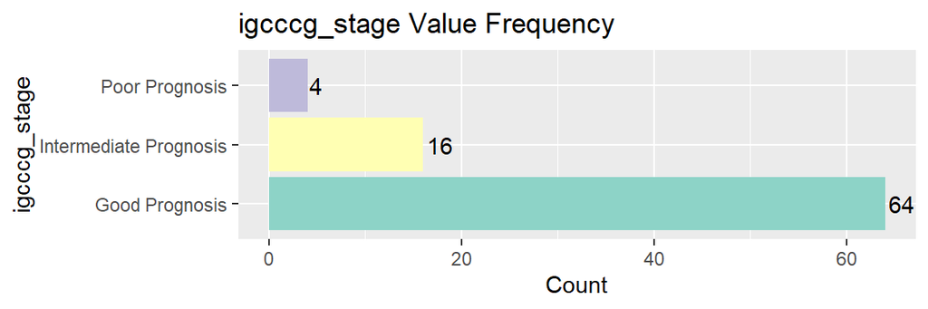

There were 30351 NA entries.

##### Unused Values:

5 values total, 2 unused

- Unknown
- Not Reported

#### **inpc_grade**

Table 28: inpc_grade Value Distribution

| inpc_grade | Frequency |
| --- | --- |
| NA | 30435 |

5 values total, all unused.

#### **inpc_histologic_group**

Table 29: inpc_histologic_group Value Distribution

| inpc_histologic_group | Frequency |
| --- | --- |
| NA | 30435 |

4 values total, all unused.

#### **inrg_stage**

Table 30: inrg_stage Value Distribution

| inrg_stage | Frequency |
| --- | --- |
| NA | 30435 |

6 values total, all unused.

#### **inss_stage**

Table 31: inss_stage Value Distribution

| inss_stage | Frequency |
| --- | --- |
| NA | 30301 |
| Stage 4 | 134 |

##### Unused Values:

8 values total, 7 unused:

- Stage 1
- Stage 2A
- Stage 2B
- Stage 3
- Stage 4S
- Unknown
- Not Reported

#### **international_prognostic_index**

Table 32: international_prognostic_index Value Distribution

| international_prognostic_index | Frequency |
| --- | --- |
| NA | 30435 |

4 values total, all unused.

#### **irs_group**

Table 33: irs_group Value Distribution

| irs_group | Frequency |
| --- | --- |
| NA | 30435 |

13 values total, all unused.

#### **irs_stage**

Table 34: irs_stage Value Distribution

| irs_stage | Frequency |
| --- | --- |
| NA | 30435 |

6 values total, all unused.

#### **ishak_fibrosis_score**

Table 35: ishak_fibrosis_score Value Distribution

| ishak_fibrosis_score | Frequency |
| --- | --- |
| NA | 30435 |

7 values total, all unused.

#### **iss_stage**

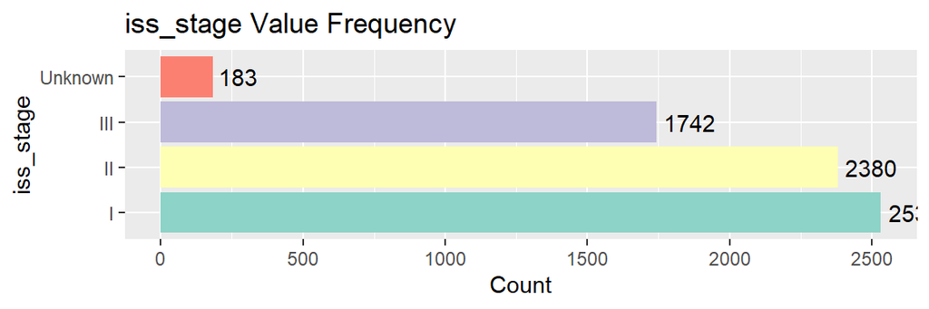

There were 23598 NA entries.

##### Unused Values:

5 values total, 1 unused

- Not Reported

#### **last_known_disease_status**

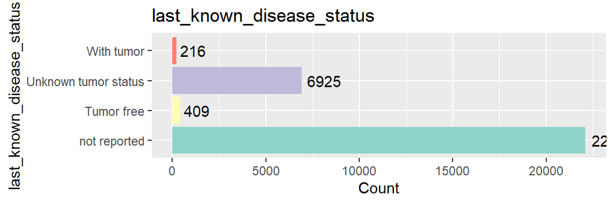

There were 785 NA entries.

##### Unused Values:

8 values total, 4 unused

- Distant met recurrence/progression
- Loco-regional recurrence/progression
- Biochemical evidence of disease without structural correlate
- Not Allowed to Collect

#### **laterality**

Table 36: Laterality Value Distribution

[output not shown]

##### Unused Values:

7 values total, 5 unused

- Bilateral
- Left
- Midline
- Unilateral
- Not Reported

#### **margins_involved_site**

Table 37: margins_involved_site Value Distribution

| margins_involved_site | Frequency |
| --- | --- |
| NA | 30435 |

8 values total, all unused.

#### **masaoka_stage**

[figure not shown]

There were 30225 NA entries.

##### Unused Values:

6 values total, all were used.

#### **medulloblastoma_molecular_classification**

Table 38: medulloblastoma_molecular_classification Value Distribution

| medulloblastoma_molecular_classification | Frequency |
| --- | --- |
| NA | 30435 |

6 values total, all unused.

#### **metastasis_at_diagnosis**

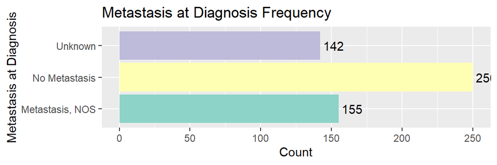

There were 29888 NA entries.

##### Unused Values:

6 values total, 3 unused.

- Distant Metastasis
- Regional Metastasis
- Not Reported

#### **metastasis_at_diagnosis_site**

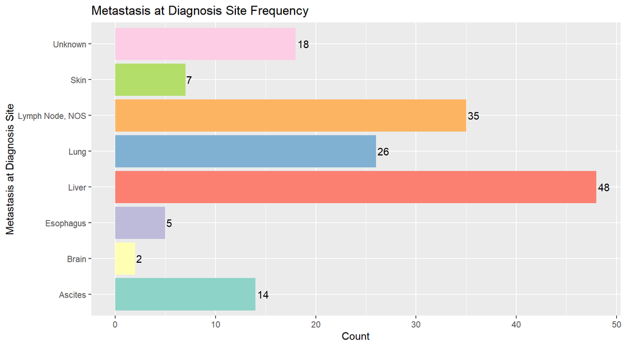

There were 30280 NA entries.

##### Unused Values:

*Abdomen*, *Adrenal Gland*, *Bladder*, *Bone*, *Bone Marrow*, *Bronchus*, *Central Nervous System*, *Cerebrospinal Fluid*, *Colon*, *Distant Nodes*, *Distant Organ*, *Gastrointestinal Tract*, *Groin*, *Head, Face or Neck, NOS*, *Heart*, *Kidney*, *Lymph Node, Axillary*, *Lymph Node, Inguinal*, *Lymph Node, Regional*, *Lymph Node, Subcarinal*, *Mediastinum*, *Neck*, *Omentum*, *Ovary*, *Pancreas*, *Pelvis*, *Peritoneal Cavity*, *Peritoneum*, *Pleura*, *Retroperitoneum*, *Scalp*, *Small Intestine*, *Soft Tissue*, *Spinal Cord*, *Urethra*, *Uterine Adnexa*, *Vertebral Canal*, *Vulva, NOS* and *Not Reported*

#### **method_of_diagnosis**

Table 38: method_of_diagnosis Value Distribution

| Method of Diagnosis | Frequency |
| --- | --- |
| NA | 30435 |

#### **mitosis_karyorrhexis_index**

Table 39: mitosis_karyorrhexis_index Distribution

| mitosis_karyorrhexis_index | Frequency |
| --- | --- |
| NA | 30435 |

5 values total, all unused.

#### **ovarian_specimen_status**

Table 40: ovarian_specimen_status Distribution

| ovarian_specimen_status | Frequency |
| --- | --- |
| NA | 30435 |

5 values total, all unused.

#### **ovarian_surface_involvement**

Table 41: ovarian_surface_involvement Distribution

| ovarian_surface_involvement | Frequency |
| --- | --- |
| NA | 30435 |

5 values total, all unused.

#### **peritoneal_fluid_cytological_status**

Table 42: peritoneal_fluid_cytological_status Distribution

| peritoneal_fluid_cytological_status | Frequency |
| --- | --- |
| NA | 30435 |

6 values total, all unused.

#### **pregnant_at_diagnosis**

Table 43: pregnant_at_diagnosis Distribution

| pregnant_at_diagnosis | Frequency |
| --- | --- |
| NA | 30435 |

4 values total, all unused.

#### **primary_gleason_grade**

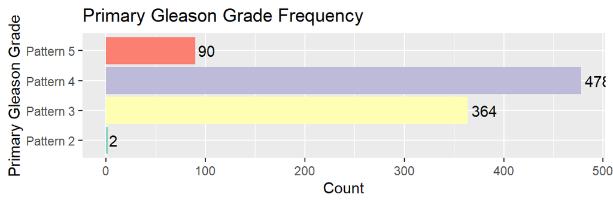

There were 29501 NA entries.

##### Unused Values:

5 values total, 1 unused.

- Pattern 1

#### **prior_malignancy**

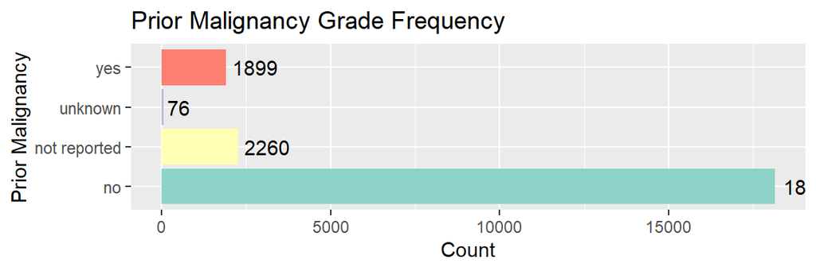

There were 8064 NA entries.

##### Unused Values:

5 values total, 1 unused.

- Not Allowed To Collect

#### **prior_treatment**

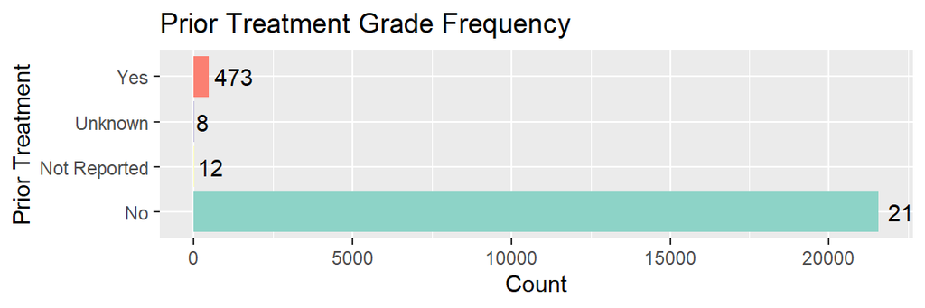

There were 8378 NA entries.

##### Unused Values:

5 values total, 1 unused.

- Not Allowed To Collect

#### **progression_or_recurrence**

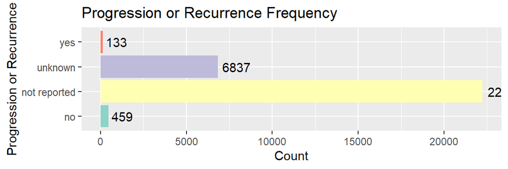

There were 785 NA entries.

##### Unused Values:

5 values total, 1 unused.

- Not Allowed To Collect

#### **residual_disease**

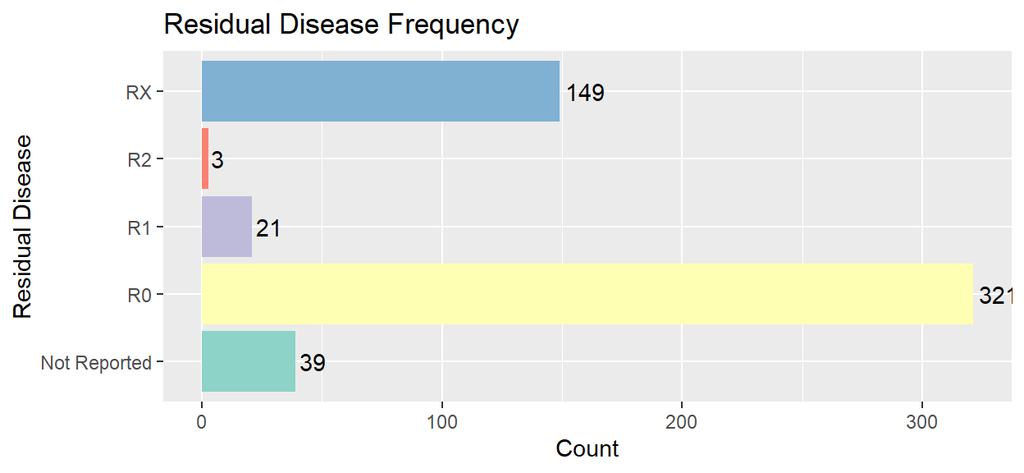

There were 29902 NA entries.

##### Unused Values:

6 values total, 1 unused.

- Unknown

#### **satellite_nodule_present**

Table 44: satellite_nodule_present Distribution

| satellite_nodule_present | Frequency |
| --- | --- |
| NA | 30435 |

5 values total, all unused.

#### **secondary_gleason_grade**

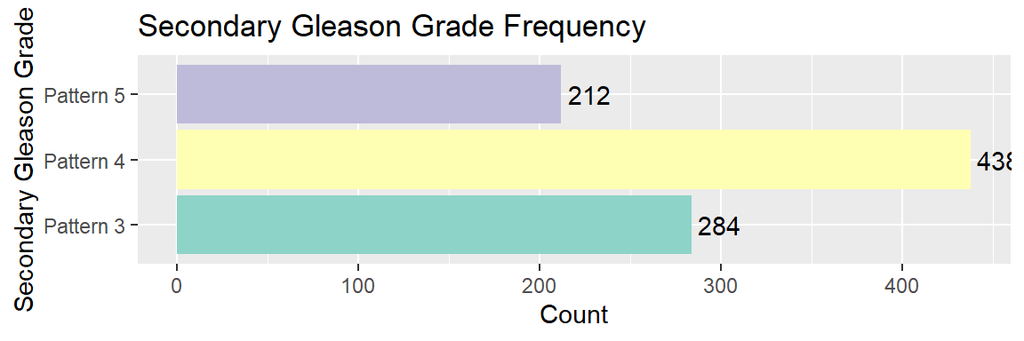

There were 29501 NA entries.

##### Unused Values:

5 values total, 2 unused.

- Pattern 1
- Pattern 2

#### **supratentorial_localization**

Table 45: supratentorial_localization Value Frequency

| supratentorial_localization | Frequency |
| --- | --- |
| NA | 30435 |

10 values total, all unused.

#### **synchronous_malignancy**

Table 46: synchronous_malignancy Value Frequency

| synchronous_malignancy | Frequency |
| --- | --- |
| NA | 8760 |
| No | 17841 |
| Not Reported | 3748 |
| Yes | 86 |

There were 8760 NA entries.

##### Unused Values:

4 values total, 1 unused

- Unknown

#### **tumor_confined_to_organ_of_origin**

Table 47: tumor_confined_to_organ_of_origin Value Frequency

| tumor_confined_to_organ_of_origin | Frequency |
| --- | --- |
| NA | 30435 |

4 values total, all unused.

#### **tumor_focality**

Table 48: tumor_focality Value Frequency

| tumor_focality | Frequency |
| --- | --- |
| NA | 30435 |

4 values total, all unused.

#### **tumor_grade**

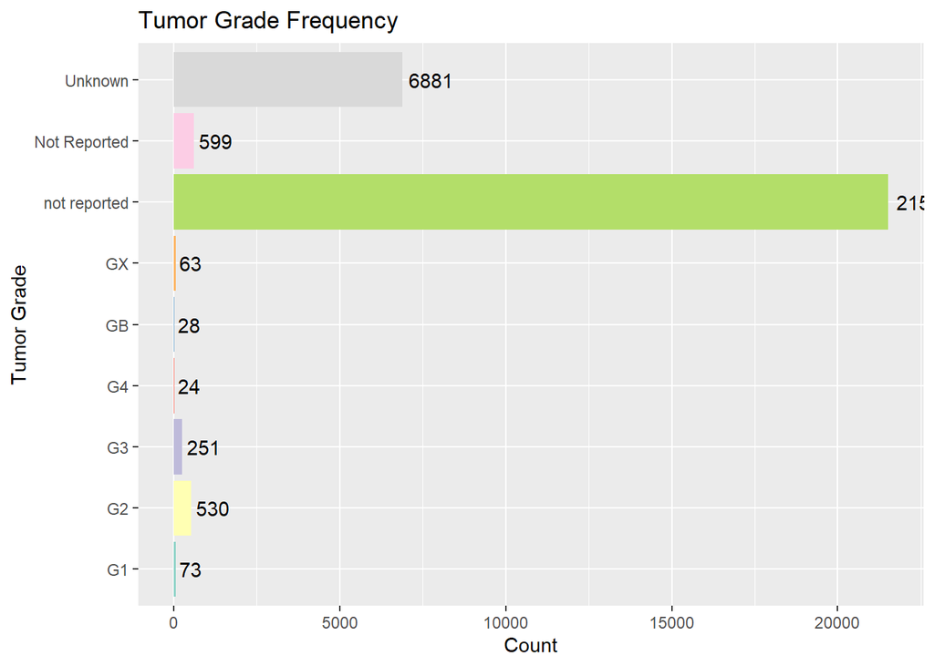

There were 476 NA entries.

“not reported” value is not present in listed enumeration in the data dictionary.

##### Unused Values:

- High Grade
- Intermediate Grade
- Low Grade

#### **tumor_regression_grade**

Table 49: tumor_regression_grade Value Frequency

| tumor_regression_grade | Frequency |
| --- | --- |
| NA | 30435 |

6 values total, all unused.

#### **weiss_assessment_score**

Table 50: weiss_assessment_score Value Frequency

| weiss_assessment_score | Frequency |
| --- | --- |
| NA | 30435 |

10 Values total, all unused.

#### **who_cns_grade**

Table 51: who_cns_grade Value Frequency

| who_cns_grade | Frequency |
| --- | --- |
| NA | 30435 |

7 values total, all unused.

#### **who_nte_grade**

Table 52: who_nte_grade Value Frequency

| who_nte_grade | Frequency |
| --- | --- |
| NA | 30435 |

6 values total, all unused.

#### **wilms_tumor_histologic_subtype**

Table 53: wilms_tumor_histologic_subtype Value Frequency

| wilms_tumor_histologic_subtype | Frequency |
| --- | --- |
| NA | 30435 |

4 values total, all unused.

## Exposure

#### **alcohol_history**

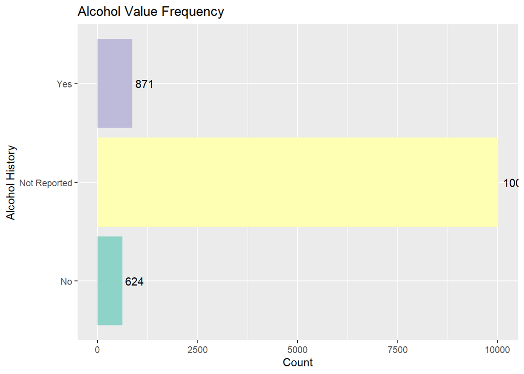

There were 77 NA entries.

##### Unused Values:

4 values total, 1 unused

- Unknown

#### **alcohol_intensity**

[figure not shown]

There were 10820 NA entries.

##### Unused Values:

- Heavy Drinker
- Not Reported

#### **alcohol_type**

Table 54: Alcohol Type Value Frequency

| Alcohol Type | Frequency |
| --- | --- |
| NA | 11585 |

6 values total, all unused.

#### **asbestos_exposure**

[output not shown]

4 values total, 2 unused

- Yes
- Not Reported

#### **coal_dust_exposure**

Table 56: Coal Dust Exposure Value Frequency

| Coal Dust Exposure | Frequency |
| --- | --- |
| NA | 11585 |

3 values total, all unused.

#### **environmental_tobacco_smoke_exposure**

Table 57: Environmental Tobacco Smoke Exposure Value Frequency

| Environmental Tobacco Smoke Exposure | Frequency |
| --- | --- |
| NA | 11585 |

3 values total, all unused.

#### **exposure_duration**

Table 58: Exposure Duration Value Frequency

| Exposure Duration | Frequency |
| --- | --- |
| NA | 11585 |

3 values total, all unknown

#### **exposure_type**

Table 59: Exposure Type VAlue Frequency

| Exposure Type | Frequency |
| --- | --- |
| NA | 11585 |

5 values total, all unused.

#### **radon_exposure**

Table 60: Radon Exposure Value Frequency

| Radon Exposure | Frequency |
| --- | --- |
| NA | 11583 |
| No | 1 |
| Unknown | 1 |

#### **respirable_crystalline_silica_exposure**

Table 61: Respirable Crystalline Silica Exposure Value Frequency

| Respirable Crystalline Silica Exposure | Frequency |
| --- | --- |
| NA | 11585 |

3 values total, all unused.

#### **secondhand_smoke_as_child**

Table 62: Secondhand Smoke Exposure as a Child Value Frequency

| Secondhand Smoke Exposure as a Child | Frequency |
| --- | --- |
| NA | 11585 |

4 values total, all unused.

#### **smoking_frequency**

Table 63: Smoking Frequency Value Frequency

| Smoking Frequency | Frequency |
| --- | --- |
| NA | 11585 |

3 values total, all unused.

#### **time_between_waking_and_first_smoke**

Table 64: time_between_waking_and_first_smoke Value Frequency

| Time Between Waking and First Smoke | Frequency |
| --- | --- |
| NA | 11585 |

5 values total, all unused.

#### **tobacco_smoking_status**

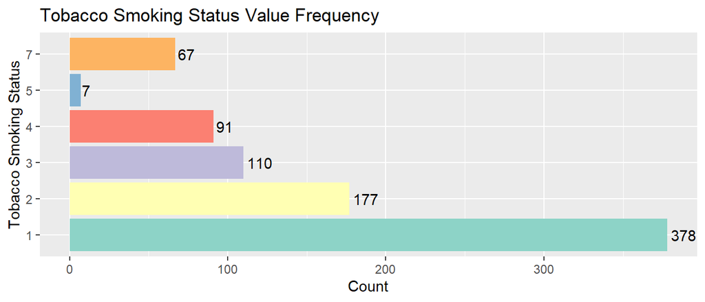

There were 10755 NA entries.

##### Unused Values:

9 values total, 3 unused.

- 6
- Unknown
- Not Reported

#### **type_of_smoke_exposure**

Table 65: Type of Smoke Exposure Value Frequency

| Type of Smoke Exposure | Frequency |
| --- | --- |
| NA | 11585 |

50 values total, all unused.

#### **type_of_tobacco_used**

Table 66: Type of Tobacco Used Value Frequency

| Type of Tobacco Used | Frequency |
| --- | --- |
| NA | 11585 |

6 values total, all unused.

## Family History

This file had no available data within.